# iml_hw4

Michal_Raszkowski

15 04 2021

W ninejszym dokumencie zajmiemy się analizą modeli za pomocą profili ceteris-paribus. Tak jak w poprzednich raportach, przyjrzymy się dwóm modelom - lasowi losowemu oraz regresji liniowej z regularyzacją elastic net, wytrenowanych na danych ‘House Sales in King County’.

### Pierwszy przykład

Zobaczmy najpierw profile zmiennych ‘grade’ oraz ‘sqft_above’ dla jednej z obserwacji ze zbioru testowego.

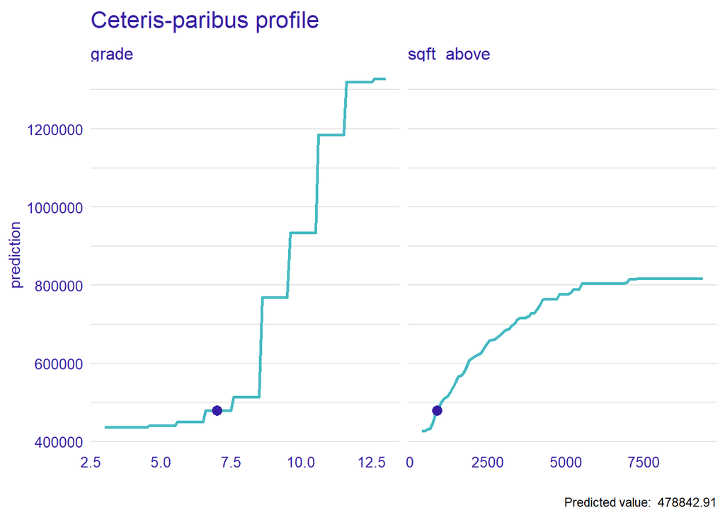

Dla powyższego przykładu ocena ‘grade’ zgodnie z intuicją ma skokowy wpływ na zmianę wartości nieruchomości. Co ciekawe, o ile wysokie noty wpływają mocno na wzrost ceny, to wartości poniżej średniej nie obniżają jej znacząco. Interesujące jest zachowanie na wykresie dla zmiennej ‘sqft_above’. Sugeruje ono (w tym przypadku) logarytmiczną zależność ceny od powierzchni mieszkania, co można by wykorzystać do implementacji prostrzych modeli (np. regresji liniowej).

### Ta sama zmienna, inny wpływ

Przyjrzyjmy się teraz wykresom zmiennej oznaczającej wiek budynku dla dwóch obserwacji.

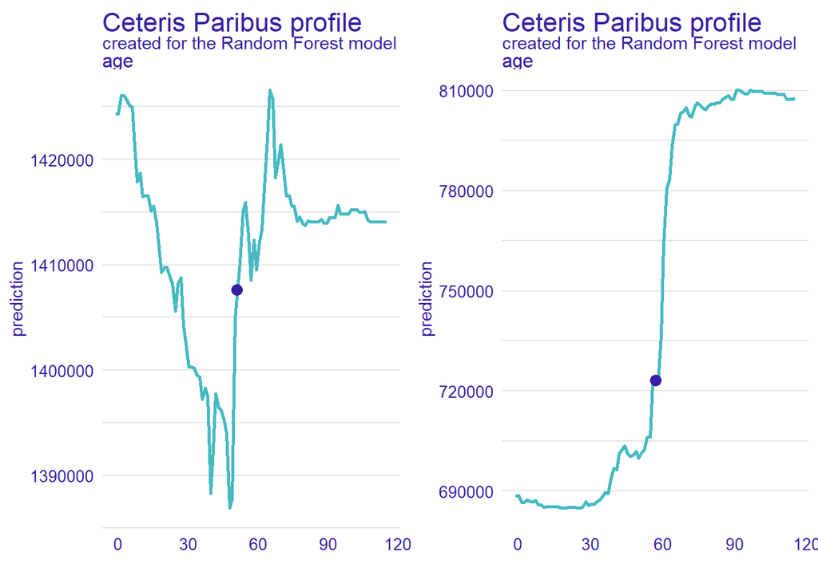

Zauważmy wpierw że dobrane obserwacje różnią się znacząco ceną. W pierwszym, droższym przykładzie mamy doczynienia z początku sensownym spadkiem ceny wraz z wiekiem budynku, jednak trend ten odwraca się i stabilizuje dla przedziału 80-120 lat. W drugim, tańszym, mamy wyraźny wzrost ceny wraz z wiekiem, co może sugerować o małej atrakcyjności nowowybudowanych nieruchomości w tym przedziale cenowym (i pozostałych parametrach) lub też atrakcyjności starszego budownictwa (być może zabytkowego). Zwróćmy uwagę, że fluktuacje dla pierwszej nieruchomości mogą wynikać z małej ilości podobnych danych oraz overfittingu modelu.

### Pierwszy przykład w modelu liniowym

Na koniec zobaczmy różnicę między modelem lasu losowego a liniowym dla zmiennej ‘age’ na naszym pierwszym przykładzie.

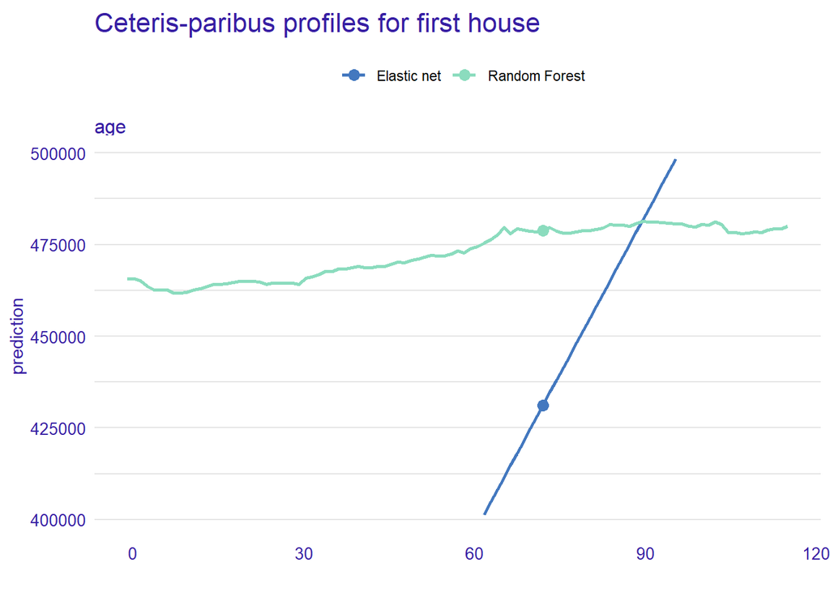

Z oczywistych względów otrzymujemy liniowy wykres dla modelu liniowego. Widać że przystosował się on do ogólnego trendu “im starsze, tym droższe”, co prawdpodobnie jest zbyt dużym uogólnieniem. Z drugiej strony las losowy dopasował się dokładniej do obserwacji o podobnych parametrach, przewidując niewielkie fluktuacje w cenie i o zdecydowanie nieliniowej zależności. Patrząc jednak na poprzednie przykłady jest to zapewne zbytnie uszczegółowienie - warto by zastosować model o mniejszej elastyczności niż nasz las losowy, ale oczywiście większej niż zwykła regresja liniowa z regularyzacją.